# Chapter 10 Exercises

```r
library(rjags)
library(coda)
## to get markdown to work I needed to create the jags txt file in a regular R.script and source the script. Check BayesianDefinitionsExercises.R
source('BayesianDefinitionsExercises.R')
```

## Exercise 1

1. *Toy snake example:* fit a two-way ANOVA with interaction to the toy example of Chapter 6 and see what happens to the nonidentifiable parameters.
1. Frequentist approach for the toy snake example

```r
##
(mod1 <- lm(mass ~ region*hab - 1 - region - hab))
```

```
Call:
lm(formula = mass ~ region * hab - 1 - region - hab)

Coefficients:
region1:hab1  region2:hab1  region1:hab2  region2:hab2  region1:hab3  region2:hab3
         6.5            NA           8.0           9.0           5.0          11.0
```

2. Now fitting the model to a Bayesian framwork: **mass ~ region*hab**

```r
data <- list(mass = mass,
             region = as.numeric(region),
             hab = as.numeric(hab),
             n = length(mass),
             n.region = n.region,
             n.hab = n.hab)
inits <- function() list(sigma = rlnorm(1))
# Parameters to estimate
params <- c("sigma", "group.mean")
# Set up Model
jagsModel <- jags.model(file = "Exercise1.Ch10.txt",
                        data = data,
                        init = inits,
                        n.chains = 3,
                        n.adapt = 2000) # Burn-in
Samples <- coda.samples(jagsModel,
                        variable.names = params,
                        n.iter = 6000) #Draws from posterior
```

```r
summary(Samples)
```

```
Iterations = 2001:8000
Thinning interval = 1
Number of chains = 3
Sample size per chain = 6000

1. Empirical mean and standard deviation for each variable,
   plus standard error of the mean:

                   Mean     SD Naive SE Time-series SE
group.mean[1,1]  6.4049  16.65   0.1241         0.1243
group.mean[2,1]  0.7088 100.59   0.7498         0.7497
group.mean[1,2]  7.6779  22.39   0.1669         0.1596
group.mean[2,2]  8.4904  22.55   0.1681         0.1818
group.mean[1,3]  4.7017  22.30   0.1662         0.1711
group.mean[2,3] 10.4692  22.72   0.1693         0.1678
sigma           16.0648  20.95   0.1562         1.7691

2. Quantiles for each variable:

                     2.5%      25%    50%    75%  97.5%
group.mean[1,1]  -31.4596   3.8037  6.511  9.157  43.04
group.mean[2,1] -197.7580 -66.7633  1.626 67.972 197.25
group.mean[1,2]  -43.6287   4.2215  7.982 11.711  58.38
group.mean[2,2]  -44.3888   5.0994  8.974 12.736  57.16
group.mean[1,3]  -46.2480   0.9561  4.951  8.640  54.75
group.mean[2,3]  -41.6538   6.8920 10.978 14.582  61.71
sigma              0.5113   2.1994  6.899 21.456  81.81
```

```r
summary(mod1)
```

```
Call:
lm(formula = mass ~ region * hab - 1 - region - hab)

Residuals:
   1    2    3    4    5    6
-0.5  0.0  0.0  0.5  0.0  0.0

Coefficients: (1 not defined because of singularities)
             Estimate Std. Error t value Pr(>|t|)
region1:hab1   6.5000     0.5000  13.000   0.0489 *
region2:hab1       NA         NA      NA       NA
region1:hab2   8.0000     0.7071  11.314   0.0561 .
region2:hab2   9.0000     0.7071  12.728   0.0499 *
region1:hab3   5.0000     0.7071   7.071   0.0894 .
region2:hab3  11.0000     0.7071  15.556   0.0409 *
---
Signif. codes:  0 ‘***’ 0.001 ‘**’ 0.01 ‘*’ 0.05 ‘.’ 0.1 ‘ ’ 1

Residual standard error: 0.7071 on 1 degrees of freedom
Multiple R-squared:  0.9987,    Adjusted R-squared:  0.992
F-statistic: 150.2 on 5 and 1 DF,  p-value: 0.06187
```

3. check for convergence

```r
gelman.diag(Samples)
```

```
Potential scale reduction factors:

                Point est. Upper C.I.
group.mean[1,1]       1.00       1.00
group.mean[2,1]       1.00       1.00
group.mean[1,2]       1.01       1.01
group.mean[2,2]       1.00       1.01
group.mean[1,3]       1.00       1.00
group.mean[2,3]       1.00       1.00
sigma                 1.01       1.02

Multivariate psrf

1
```

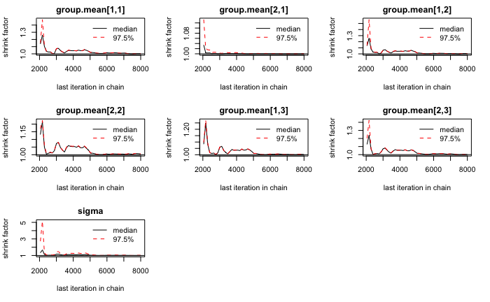

```r
gelman.plot(Samples)
```

Non-identifiability in a Bayesian analysis is perhaps slightly less easily diagnosed than in a classical analysis, since there is always some information about a parameter: if there is none in the data, then it comes from the prior. In our analysis, we have no information on snakes in habitat 1 in region 2, hence the posterior distribution for the associated parameter is determined by the prior. We recognize that by the huge range of the posterior of group.mean[2,1].

## Exercise 2

2. *Swiss har data:* Fit an ANOVA model to mean hear density to decide whether the effects of greassland and arable land use is the same in all regions. Regions and land use are somewhat confounded, but we ignore this here.

```r
hare <- read.table("hares.data.txt", header = TRUE,  sep = "\t")
```

1. Frequentist approach

```r
with(hare, aggregate(mean.density, by = list(region, landuse), FUN = mean, na.rm = TRUE))
```

| Group.1 | Group.2 | x |
| --- | --- | --- |
| Aare | arable | 5.1896383 |
| Baselland | arable | 3.1404375 |
| CH.Central | arable | 2.6076820 |
| CH.E | arable | 3.2362653 |
| CH.N | arable | 5.2561169 |
| CH.SW | arable | 9.6205801 |
| CH.W | arable | 5.1190322 |
| Rhone | arable | 4.4633921 |
| Aare | grass | 2.4493494 |
| Baselland | grass | 2.8639833 |

[output cut: 3 more lines]

```r
with(hare, table(region, landuse))
```

```
            landuse
region       arable grass
  Aare          221    51
  Baselland      17    34
  CH.Central     68    51
  CH.E           34   119
  CH.N          102     0
  CH.SW          68     0
  CH.W          136     0
  Rhone          34    17
```

```r
hare$region <- as.factor(as.numeric(hare$region))
hare$landuse <- as.factor(as.numeric(hare$landuse))
summary(mod2 <- lm(mean.density ~ region*landuse - 1 - region - landuse, data = hare))
```

```
Call:
lm(formula = mean.density ~ region * landuse - 1 - region - landuse,
    data = hare)

Residuals:
    Min      1Q  Median      3Q     Max
-6.9006 -2.2629 -0.4904  1.6232 16.9740

Coefficients: (3 not defined because of singularities)
                 Estimate Std. Error t value Pr(>|t|)
region1:landuse1   5.1896     0.2919  17.779  < 2e-16 ***
region2:landuse1   3.1404     0.9195   3.415 0.000676 ***
region3:landuse1   2.6077     0.4511   5.780 1.15e-08 ***
region4:landuse1   3.2363     0.7234   4.473 9.06e-06 ***
region5:landuse1   5.2561     0.3778  13.912  < 2e-16 ***
region6:landuse1   9.6206     0.4050  23.753  < 2e-16 ***
region7:landuse1   5.1190     0.3267  15.671  < 2e-16 ***
region8:landuse1   4.4634     0.6630   6.732 3.63e-11 ***
region1:landuse2   2.4493     0.7814   3.135 0.001797 **
region2:landuse2   2.8640     0.6502   4.405 1.23e-05 ***
region3:landuse2   2.6347     0.5309   4.963 8.83e-07 ***
region4:landuse2   3.8197     0.3349  11.406  < 2e-16 ***
region5:landuse2       NA         NA      NA       NA
region6:landuse2       NA         NA      NA       NA
region7:landuse2       NA         NA      NA       NA
region8:landuse2   0.5441     1.2530   0.434 0.664295
---
Signif. codes:  0 ‘***’ 0.001 ‘**’ 0.01 ‘*’ 0.05 ‘.’ 0.1 ‘ ’ 1

Residual standard error: 3.315 on 664 degrees of freedom
  (275 observations deleted due to missingness)
Multiple R-squared:  0.7085,    Adjusted R-squared:  0.7028
F-statistic: 124.2 on 13 and 664 DF,  p-value: < 2.2e-16
```

2. Bayesian approach

```r
## lm(mean.density ~ region*landuse, data = hare))
data <- with(hare, list(mean.density = mean.density,
             region = as.numeric(region),
             landuse = as.numeric(landuse),
             n = length(mean.density),
             n.region = length(unique(region)),
             n.landuse = length(unique(landuse))))
inits <- function() list(sigma = rlnorm(1))
# Parameters to estimate
params <- c("sigma", "group.mean", "diff.density")
# Set up Model
jagsModel <- jags.model(file = "Exercise2.Ch10.txt",
                        data = data,
                        init = inits,
                        n.chains = 3,
                        n.adapt = 2000) # Burn-in
Samples <- coda.samples(jagsModel,
                        variable.names = params,
                        n.iter = 6000) #Draws from posterior
```

```r
summary(Samples)
```

```
Iterations = 2001:8000
Thinning interval = 1
Number of chains = 3
Sample size per chain = 6000

1. Empirical mean and standard deviation for each variable,
   plus standard error of the mean:

                    Mean        SD  Naive SE Time-series SE
diff.density[1]  2.74746   0.83329 0.0062110      0.0062592
diff.density[2]  0.29161   1.12915 0.0084162      0.0084633
diff.density[3] -0.02779   0.70140 0.0052280      0.0052277
diff.density[4] -0.57978   0.79389 0.0059173      0.0059573
diff.density[5]  5.21520 100.26494 0.7473307      0.7640076
diff.density[6]  8.82619 100.05480 0.7457644      0.7481439
diff.density[7]  4.46024  99.49300 0.7415770      0.7502160
diff.density[8]  3.91701   1.43088 0.0106651      0.0106652
group.mean[1,1]  5.19220   0.29153 0.0021730      0.0021729
group.mean[2,1]  3.15960   0.92718 0.0069108      0.0069106
group.mean[3,1]  2.60911   0.45564 0.0033961      0.0033805
group.mean[4,1]  3.23894   0.72128 0.0053761      0.0054226
group.mean[5,1]  5.25301   0.38167 0.0028448      0.0028449
group.mean[6,1]  9.61638   0.40383 0.0030099      0.0030105
group.mean[7,1]  5.11826   0.32950 0.0024560      0.0024559
group.mean[8,1]  4.46325   0.66780 0.0049775      0.0048777
group.mean[1,2]  2.44473   0.78428 0.0058457      0.0058749
group.mean[2,2]  2.86799   0.64957 0.0048416      0.0049510
group.mean[3,2]  2.63689   0.53258 0.0039696      0.0039004
group.mean[4,2]  3.81872   0.33706 0.0025123      0.0025122
group.mean[5,2]  0.03781 100.26422 0.7473254      0.7640170
group.mean[6,2]  0.79018 100.05283 0.7457498      0.7480815
group.mean[7,2]  0.65802  99.49048 0.7415583      0.7501531
group.mean[8,2]  0.54624   1.26157 0.0094032      0.0094684
sigma            3.32188   0.09178 0.0006841      0.0009089

2. Quantiles for each variable:

                     2.5%      25%      50%      75%    97.5%
diff.density[1]    1.1131   2.1822  2.75548  3.30893   4.3834
diff.density[2]   -1.9164  -0.4684  0.29282  1.05200   2.5107
```

[output cut: 8 more lines]

```
group.mean[3,1]    1.7143   2.3017  2.61143  2.92017   3.4984
group.mean[4,1]    1.8246   2.7452  3.24152  3.73085   4.6547
group.mean[5,1]    4.5102   4.9984  5.25365  5.50871   6.0090
group.mean[6,1]    8.8245   9.3421  9.61578  9.88646  10.4094
group.mean[7,1]    4.4720   4.8969  5.11883  5.34033   5.7774
group.mean[8,1]    3.1485   4.0112  4.46637  4.91221   5.7879
group.mean[1,2]    0.9123   1.9205  2.43635  2.97974   3.9710
group.mean[2,2]    1.5887   2.4332  2.86630  3.30768   4.1347
group.mean[3,2]    1.5952   2.2782  2.63149  2.99709   3.7001
group.mean[4,2]    3.1626   3.5889  3.81842  4.04416   4.4764
group.mean[5,2] -196.9724 -67.1425  0.65204 67.73004 195.6163
group.mean[6,2] -195.8913 -66.8337  1.28403 68.55431 194.5687
group.mean[7,2] -194.6450 -66.9924 -0.41999 68.19097 193.7987
group.mean[8,2]   -1.9325  -0.3021  0.55260  1.39007   3.0161
sigma              3.1474   3.2587  3.31978  3.38152   3.5089
```

```r
summary(mod2)
```

```
Call:
lm(formula = mean.density ~ region * landuse - 1 - region - landuse,
    data = hare)

Residuals:
    Min      1Q  Median      3Q     Max
-6.9006 -2.2629 -0.4904  1.6232 16.9740

Coefficients: (3 not defined because of singularities)
                 Estimate Std. Error t value Pr(>|t|)
region1:landuse1   5.1896     0.2919  17.779  < 2e-16 ***
region2:landuse1   3.1404     0.9195   3.415 0.000676 ***
region3:landuse1   2.6077     0.4511   5.780 1.15e-08 ***
region4:landuse1   3.2363     0.7234   4.473 9.06e-06 ***
region5:landuse1   5.2561     0.3778  13.912  < 2e-16 ***
region6:landuse1   9.6206     0.4050  23.753  < 2e-16 ***
region7:landuse1   5.1190     0.3267  15.671  < 2e-16 ***
region8:landuse1   4.4634     0.6630   6.732 3.63e-11 ***
region1:landuse2   2.4493     0.7814   3.135 0.001797 **
region2:landuse2   2.8640     0.6502   4.405 1.23e-05 ***
region3:landuse2   2.6347     0.5309   4.963 8.83e-07 ***
region4:landuse2   3.8197     0.3349  11.406  < 2e-16 ***
region5:landuse2       NA         NA      NA       NA
region6:landuse2       NA         NA      NA       NA
region7:landuse2       NA         NA      NA       NA
region8:landuse2   0.5441     1.2530   0.434 0.664295
---
Signif. codes:  0 ‘***’ 0.001 ‘**’ 0.01 ‘*’ 0.05 ‘.’ 0.1 ‘ ’ 1

Residual standard error: 3.315 on 664 degrees of freedom
  (275 observations deleted due to missingness)
Multiple R-squared:  0.7085,    Adjusted R-squared:  0.7028
F-statistic: 124.2 on 13 and 664 DF,  p-value: < 2.2e-16
```

## Convergence

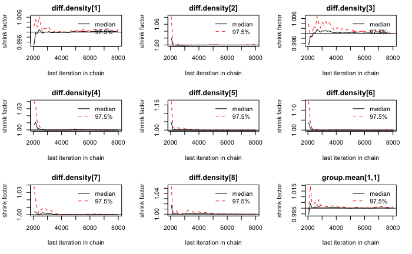

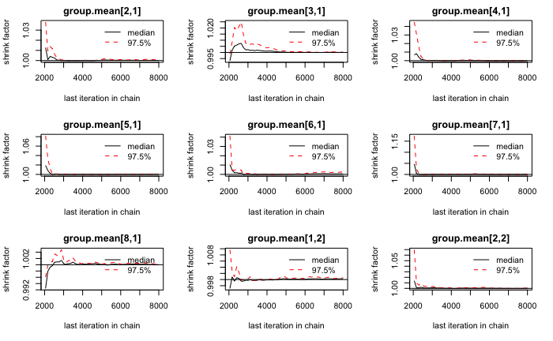

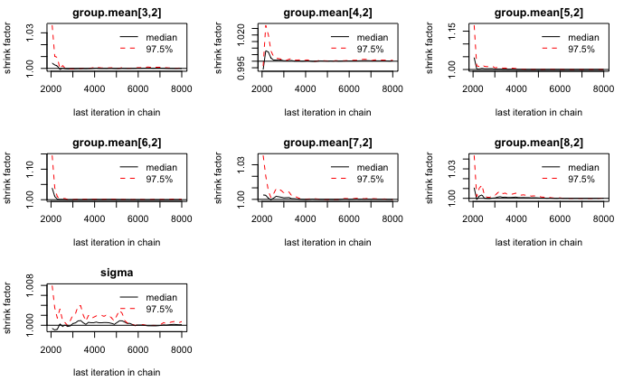

```r
# plot(Samples)
# gelman.diag(Samples)
gelman.plot(Samples)
```

In addition, the difference in mean density between the two landuse types in the eight regions seems to differ quite a bit, as we can see from the estimates of the diff.density nodes. (Those for which there is no information for both arable and grassland again have huge posterior sd’s and 95% CRI’s).